# gaku Template

#### google sheet

https://googlesheets4.tidyverse.org/

- sample code

```r
library(googlesheets4)
library(googledrive)

###   save at google sheet
System_Time <- format(Sys.time(), "%Y-%m-%d_%H:%M")
Output_Sheet_Name <- paste("GFW_COVID_Project_1_Tables",System_Time, sep = "")

Results_at_GSheet <- gs4_create(Output_Sheet_Name,
  sheets = list(Summary_Vessel_Size = Summary_Vessel_Size,
                Summary_Gear = Summary_Gear,
                Summary_Longline_Vessel_Prefecture = Summary_Longline_Vessel_Prefecture))

# URL
read_sheet("https://docs.google.com/spreadsheets/d/1U6Cf_qEOhiR9AZqTqS3mbMF3zt2db48ZP5v3rkrAEJY/edit#gid=780868077")

# Sheet ID
read_sheet("1U6Cf_qEOhiR9AZqTqS3mbMF3zt2db48ZP5v3rkrAEJY")

# a googledrive "dribble"
googledrive::drive_get("gapminder") %>%
  read_sheet()
```

#### flexdashboard

https://pkgs.rstudio.com/flexdashboard/

### Spark

- 高速に分散処理を行うオープンソースのフレームワーク
- [sparklyr](https://spark.rstudio.com/)
- [Mastering Spark with R](https://therinspark.com/)
- Sparkのphilosophyは、すべてを `double type`にする。そのため、Rにもどす時に、categoricalやlogicalにコンバートが必要。

```r
library(sparklyr)
library(tidyverse)
library(nycflights13) # install.packages(c("nycflights13", "Lahman"))

#spark_install() # これを最初にはしらせて　sparkをインストールが必要
spark_conn_TEST <- spark_connect(master = "local")
# Print the version of Spark
spark_version(sc = spark_conn_TEST)

TEST_Data <- nycflights13::flights
object.size(TEST_Data)

TEST_tbl <- copy_to(spark_conn_TEST, TEST_Data)

src_tbls(spark_conn_TEST)

TEST_tbl_2 <- tbl(spark_conn_TEST, "test_data")

# Disconnect from Spark
spark_disconnect(sc = spark_conn_TEST)
```

- 全てのデータは、リモートデータベース(もしくはローカル)になっている。

```r
library(sparklyr)
library(tidyverse)
library(nycflights13)

spark_conn_TEST <- spark_connect(master = "local")
# Print the version of Spark
spark_version(sc = spark_conn_TEST)

#  all sould be lower case
test_data <- nycflights13::flights
test_tbl <- copy_to(spark_conn_TEST, test_data)

results <- test_tbl %>% filter(month == 1)

# data is at the remote database @spark
class(results)

# collect results from spark
collected <- results %>% collect()

class(collected)

# Disconnect from Spark
spark_disconnect(sc = spark_conn_TEST)
```

### Visualization

- [ggplot2](https://ggplot2-book.org/)
- [R Graphics Cookbook, 2nd edition](https://r-graphics.org/)
- [Interactive web-based data visualization with R, plotly, and shiny](https://plotly-r.com/)
- [Hands-On Machine Learning with R](https://bradleyboehmke.github.io/HOML/index.html)

### Benchmarking & Environment

```r
R.version
```

```
##                _
## platform       x86_64-apple-darwin17.0
## arch           x86_64
## os             darwin17.0
## system         x86_64, darwin17.0
## status
## major          4
## minor          1.0
## year           2021
## month          05
## day            18
## svn rev        80317
## language       R
## version.string R version 4.1.0 (2021-05-18)
## nickname       Camp Pontanezen
```

```r
library("microbenchmark")

colon <- function (n) 1:n

seq_default <- function(n) seq(1:n)

seq_by <- function(n) seq(1, n, by = 1)

system.time(res <- colon(1e8))

n <- 1e8

microbenchmark(colon(n),
               seq_default(n),
               seq_by(n),
               times =10) # run 10 times
```

```r
library(benchmarkme)
get_ram()
get_cpu()

res <- benchmark_io(runs = 1, size =5)
plot(res)
```

- code profiling

```r
library("ggplot2movies")
library("profvis")


data(movies, package = "ggplot2movies")
dim(movies)

Sleepless_in_Seattle <- movies[47412,]
movies_drama <- movies[movies$Drama ==1, ]

movies_drama %>% ggplot(aes(x = year, y = rating)) +
  geom_point(alpha =0.05) +
  xlab("Year") + ylab("Rating") +
  geom_point(aes(Sleepless_in_Seattle$year,
             Sleepless_in_Seattle$rating),
             colour = "#E16B8C") +
  geom_smooth(method = "loess", colour = "#2EA9DF")

###

profvis::profvis({
data(movies, package = "ggplot2movies")
dim(movies)

Sleepless_in_Seattle <- movies[47412,]
movies_drama <- movies[movies$Drama ==1, ]

movies_drama %>% ggplot(aes(x = year, y = rating)) +
  geom_point(alpha =0.05) +
  xlab("Year") + ylab("Rating") +
  geom_point(aes(Sleepless_in_Seattle$year,
             Sleepless_in_Seattle$rating),
             colour = "#E16B8C") +
  geom_smooth(method = "loess", colour = "#2EA9DF")
})

#######
```

### Database

- [Database Queries With R](https://db.rstudio.com/getting-started/database-queries/)
- [Using dplyr with databases](https://db.rstudio.com/r-packages/dplyr/)
- [Google BigQuery](https://db.rstudio.com/databases/big-query/)
- [DataCamp: Intermediate Importing Data in R](https://app.datacamp.com/learn/courses/intermediate-importing-data-in-r)

#### API

- API Application Programming Interfaces
- [R API Tutorial: Getting Started with APIs in R](https://www.dataquest.io/blog/r-api-tutorial/)
- 基本のGETとPOST リクエスト

```r
#install.packages(c("httr", "jsonlite"))
library(httr)
library(jsonlite)

library(pageviews)
```

#### 海知る

- [海知るAPI](https://portal.msil.go.jp/apis)

```r
library(httr)
umishiru_Result_1 <- GET(url="https://api.msil.go.jp/apis/v1/", query=list(api_key = gaku_key))
str(umishiru_Result_1 )
```

[output not shown]

#### estat access

- [estatapi - 政府統計の総合窓口（e-Stat）のAPIを使うためのRパッケージ](https://yutannihilation.github.io/estatapi/)

```r
# install.packages("estatapi")
library(estatapi)
estat_Result_1 <-estatapi::estat_getStatsList(appId = appId_estat_gakuLab, searchWord = "魚種" )

head(estat_Result_1)
```

```
## # A tibble: 6 × 25
##   `@id`      STAT_NAME GOV_ORG STATISTICS_NAME TITLE CYCLE SURVEY_DATE OPEN_DATE
##   <chr>      <chr>     <chr>   <chr>           <chr> <chr> <chr>       <chr>
## 1 0003228937 海面漁業… 農林水… 海面漁業生産統… 海面… 年次  200301-200… 2019-01-…
## 2 0003228938 海面漁業… 農林水… 海面漁業生産統… 海面… 年次  200301-200… 2019-01-…
## 3 0003228939 海面漁業… 農林水… 海面漁業生産統… 海面… 年次  200301-200… 2019-01-…
## 4 0003228940 海面漁業… 農林水… 海面漁業生産統… 海面… 年次  200301-200… 2019-01-…
## 5 0003228941 海面漁業… 農林水… 海面漁業生産統… 海面… 年次  200301-200… 2019-01-…
## 6 0003228942 海面漁業… 農林水… 海面漁業生産統… 海面… 年次  200301-200… 2019-01-…
## # … with 17 more variables: SMALL_AREA <chr>, COLLECT_AREA <chr>,
## #   MAIN_CATEGORY <chr>, SUB_CATEGORY <chr>, OVERALL_TOTAL_NUMBER <chr>,
## #   UPDATED_DATE <chr>, TABULATION_CATEGORY <chr>,
## #   TABULATION_SUB_CATEGORY1 <chr>, TABULATION_SUB_CATEGORY2 <chr>,
## #   DESCRIPTION <chr>, TABLE_CATEGORY <chr>, TABLE_NAME <chr>,
## #   TABLE_EXPLANATION <chr>, TABLE_SUB_CATEGORY1 <chr>,
## #   TABLE_SUB_CATEGORY2 <chr>, TABLE_SUB_CATEGORY3 <chr>, …
```

### Latex

- [Aligning_equations](https://www.overleaf.com/learn/latex/Aligning_equations_with_amsmath)

### Parallel computing

- [Quick Intro to Parallel Computing in R](https://nceas.github.io/oss-lessons/parallel-computing-in-r/parallel-computing-in-r.html)
- https://bookdown.org/rdpeng/rprogdatascience/parallel-computation.html

```r
library(parallel)
library("microbenchmark")

detectCores()
ncores <- detectCores(logical = FALSE)
n <- ncores:1

lapply(n, rnorm, mean = 10, sd =2)

cl <- makeCluster(ncores)
clusterApply(cl, n, fun = rnorm, mean =10, sd =2 )
```

#### Socket VS Folk

### Analysis

- [探索的データ分析](https://uribo.github.io/practical-ds/01/eda.html)

### General

#### ギリシャ文字表

| 文字 | 名称 | 文字 | 名称 |
| --- | --- | --- | --- |
| $\alpha$ | アルファ | $\nu$ | ニュー |
| $\beta$ | ベータ | $\xi$ | クシー |
| $\gamma$ | ガンマ | $\omicron$ | オミクロン |
| $\delta$ | デルタ | $\pi$ | パイ |
| $\epsilon$ | イプシロン | $\rho$ | ロー |
| $\zeta$ | ゼータ | $\sigma$ | シグマ |
| $\eta$ | エータ（イータ） | $\tau$ | タウ |
| $\theta$ | テータ（シータ） | $\upsilon$ | ユプシロン |
| $\iota$ | イオタ | $\phi$ | フィー |
| $\kappa$ | カッパ | $\chi$ | キー |
| $\lambda$ | ラムダ | $\psi$ | プシー |
| $\mu$ | ミュー | $\omega$ | オメガ |

#### ギリシャ文字表(大文字)

| 文字 | 名称 | 文字 | 名称 |
| --- | --- | --- | --- |
| $A$ | アルファ | $N$ | ニュー |
| $B$ | ベータ | $\Xi$ | クシー |
| $\Gamma$ | ガンマ | $O$ | オミクロン |
| $\Delta$ | デルタ | $\Pi$ | パイ |
| $E$ | イプシロン | $P$ | ロー |
| $Z$ | ゼータ | $\Sigma$ | シグマ |
| $H$ | エータ（イータ） | $T$ | タウ |
| $\Theta$ | テータ（シータ） | $\Upsilon$ | ユプシロン |
| $I$ | イオタ | $\Phi$ | フィー 又は ファイ |
| $K$ | カッパ | $X$ | キー 又は カイ |
| $\Lambda$ | ラムダ | $\Psi$ | プシー |
| $M$ | ミュー | $\Omega$ | オメガ |

#### ギリシャ文字表(小文字 var)

| 文字 | 名称 |
| --- | --- |
| $\varepsilon$ | イプシロン |
| $\vartheta$ | テータ（シータ） |
| $\varrho$ | ロー |
| $\varsigma$ | シグマ |
| $\varphi$ | フィー 又は ファイ |

#### 記号の読み方

| 記号 | 意味 | 読み方 日本語 | 読み方 英語 |
| --- | --- | --- | --- |
| $x \in A$ | ｘはAに属する |  | x in A / x belonging to A |

# 2 $~~$Project

## Overview

### Note

### Log

# 3 $~~$Environment

## 3.1 Clear all variables

```r
# 現在の環境にある変数の消去
rm(list = ls("all.names" = TRUE))
```

## 3.2 Load library

### Packages General

```r
library(tidyverse)

library(data.table)

library(DT)
# https://rstudio.github.io/DT/005-bootstrap.html
# https://kazutan.github.io/kazutanR/DT_demo.html
```

### Packages Peoject

```r
library(ggformula)  # http://www.mosaic-web.org/ggformula/

library(latex2exp)

library(ggsci)

library(googlesheets4)

library(ggpubr)

# https://r-coder.com/economics-charts-r/
#library(econocharts)

#library(reconPlots)
```

### Packages Experimental

# 4 $~$Data

**Data List**

## 4.1 Data load (import)

## 4.2 Explonatory data analysis

# Grammer of Grapghics

- サンプルとしてテンプレートに入れる。

## GG concepts by Leland Wikinson

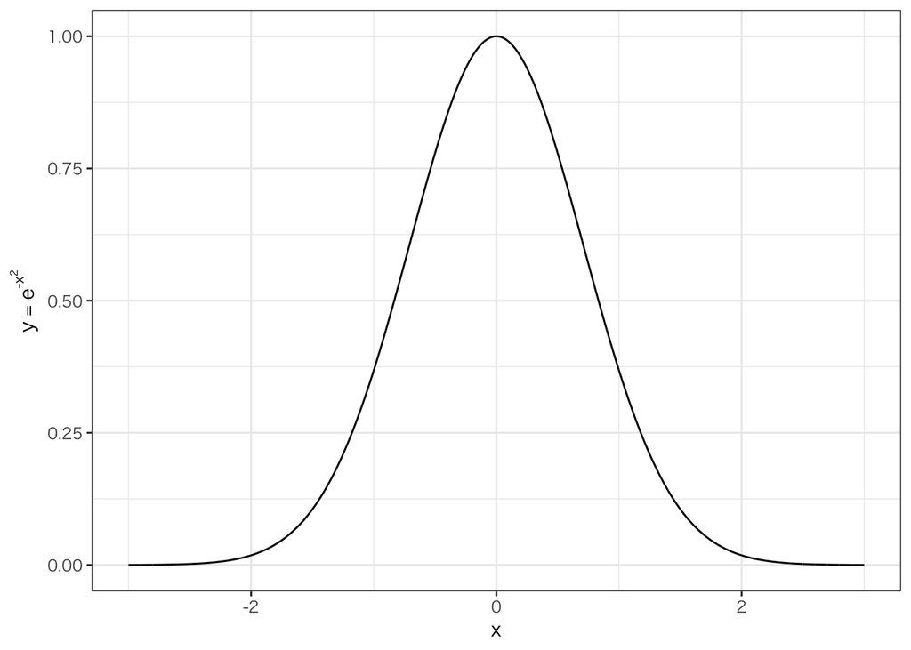

```r
Data_1 <- tibble(x = seq(-3,3, by=.001), y = exp(-x^2))

Data_1 %>% ggplot(aes(x,y)) +
  geom_line() +
  labs(y = TeX('$y = e^{-x^2}$'), x = "x") +
  theme_bw(base_family = "HiraKakuProN-W3")
```